# Projeto 1 - Exemplos de Euler - crescimento geométrico

João Victor Dell Agli Floriano, 10799783

Para esse projeto, serão resolvidos três problemas propostos por Euler em seu livro "Introductio in Analysin Infinitorum" de 1748. Para isso, usaremos as seguintes bilbiotecas:

```python
import matplotlib.pyplot as plt
import numpy as np
```

## Problemas

### Se a população de uma determinada região aumentar anualmente de um trigésimo e, a certa altura, houver 100 000 habitantes, queremos conhecer a população 100 anos depois.

Supondo a situação acima:

```python
# Setup de variáveis
r = 1.0 + 1.0/30.0
p_0 = 1e5
n = 100
```

Pode-se calcular a a evolução anual da população a partir da seguinte fórmula:

$ P_{n+1} = r P_{n}$

Que nos mostra que a população no ano seguinte ($P_{n+1}$) será a população atual ($P_n$) aumentada de uma taxa ($r$):

```python
p_n = np.zeros(n + 1)
p_n[0] = p_0

for i in range(n):

    p_n[i + 1] = r*p_n[i]
```

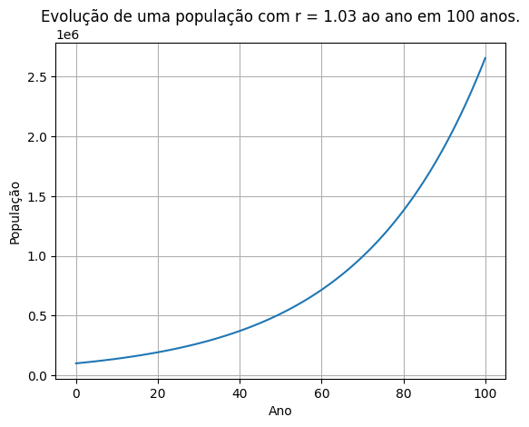

```python
ns = np.arange(0, n+1, 1)
plt.plot(ns, p_n)
plt.title(f"Evolução de uma população com r = {round(r, 2)} ao ano em {n} anos.")
plt.xlabel("Ano")
plt.ylabel("População")
plt.grid()
```

Se a população do ano seguinte é igual a do ano anterior multiplicada por $r$, portanto pode-se traduzir a regra iterativa para a fórmula analítica final:

$P_n = r^n P_0$

Nos permitindo encontrar a população $P_n$ a partir da população inicial $P_0$ após $n$ anos:

```python
p_n = r**(n)*p_0
print(f"A população após {n} anos será de, aproximadamente,", round(p_n), "habitantes.")
```

```
A população após 100 anos será de, aproximadamente, 2654874 habitantes.
```

### Uma vez que, após o Dilúvio, todos os homens descenderam de uma população de seis elementos, e supondo que a população duzentos anos depois era de 1 000 000, queremos determinar a taxa de crescimento anual.

Supondo a situação acima, e a partir da relação analítica encontrada no exemplo anterior, a taxa $r$ pode ser encontrada como:

$r = (\frac{P_n}{P_0})^{\frac{1}{n}}$

```python
# Setup de variáveis
p_0 = 6
p_n = 1e6
n = 200
```

```python
r = (p_n/p_0)**(1/n)

print(f"A taxa de crescimento dessa população após {n} anos é de", r)
print(f"Ou seja, ela cresce {round(100*(r - 1), 2)}% ao ano.")
```

```
A taxa de crescimento dessa população após 200 anos é de 1.0619626529033215
Ou seja, ela cresce 6.2% ao ano.
```

### Se a população humana aumentar anualmente de 1/100, gostaríamos de saber quanto tempo será preciso para que a população se torne dez vezes maior.

Usando novamente a relação analítica encontrada anteriormente, o tempo necessário para que a população seja $10x$ maior pode ser encontrado como:

$\frac{P_n}{P_0} = r^n = 10$

$n \log _r r = \log _r 10$

$n = \log _r 10$

```python
r = 1 + 1/100
scale = 10
n = round(np.log(scale)/np.log(r), 2)

print(f"O tempo necessário para que a população com crescimento \
de {round(r, 2)} seja {scale}x maior é de {round(np.log(scale)/np.log(r), 2)} anos.")
```

```
O tempo necessário para que a população com crescimento de 1.01 seja 10x maior é de 231.41 anos.
```

Podemos também, nesse caso, visualizar a evolução do tamanho desta população ao longo da quantidade de anos encontrada:

```python
n = round(n)

scales = np.zeros(n + 1)
scales[0] = 1
ys = np.arange(0, n + 1, 1)

scales = r**ys
```

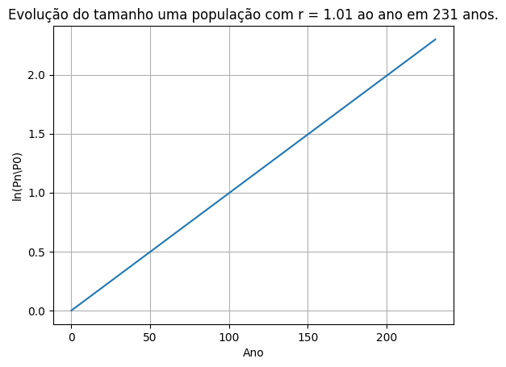

```python
plt.plot(ys, np.log(scales))
plt.title(f"Evolução do tamanho uma população com r = {round(r, 2)} ao ano em {n} anos.")
plt.xlabel("Ano")
plt.ylabel("ln(Pn\P0)")
plt.grid(True)
```